# About Fuel Economy dataset

The fuel economy of an automobile is the fuel efficiency relationship between the distance traveled and the amount of fuel consumed by the vehicle. Consumption can be expressed in terms of volume of fuel to travel a distance, or the distance travelled per unit volume of fuel consumed.

# step(1):-Gathering Data

```python
import pandas as pd
import numpy as np
import matplotlib.pyplot as plt

%matplotlib inline
```

```python
df_08=pd.read_csv('E:/data analysis project/project_2/fuel_economy_datasets/all_alpha_08.csv')
df_08.head(5)
```

|  | Model | Displ | Cyl | Trans | Drive | Fuel | Sales Area | Stnd | Underhood ID | Veh Class | Air Pollution Score | FE Calc Appr | City MPG | Hwy MPG | Cmb MPG | Unadj Cmb MPG | Greenhouse Gas Score | SmartWay |
| --- | --- | --- | --- | --- | --- | --- | --- | --- | --- | --- | --- | --- | --- | --- | --- | --- | --- | --- |
| 0 | ACURA MDX | 3.7 | (6 cyl) | Auto-S5 | 4WD | Gasoline | CA | U2 | 8HNXT03.7PKR | SUV | 7 | Drv | 15 | 20 | 17 | 22.0527 | 4 | no |
| 1 | ACURA MDX | 3.7 | (6 cyl) | Auto-S5 | 4WD | Gasoline | FA | B5 | 8HNXT03.7PKR | SUV | 6 | Drv | 15 | 20 | 17 | 22.0527 | 4 | no |
| 2 | ACURA RDX | 2.3 | (4 cyl) | Auto-S5 | 4WD | Gasoline | CA | U2 | 8HNXT02.3DKR | SUV | 7 | Drv | 17 | 22 | 19 | 24.1745 | 5 | no |
| 3 | ACURA RDX | 2.3 | (4 cyl) | Auto-S5 | 4WD | Gasoline | FA | B5 | 8HNXT02.3DKR | SUV | 6 | Drv | 17 | 22 | 19 | 24.1745 | 5 | no |
| 4 | ACURA RL | 3.5 | (6 cyl) | Auto-S5 | 4WD | Gasoline | CA | U2 | 8HNXV03.5HKR | midsize car | 7 | Drv | 16 | 24 | 19 | 24.5629 | 5 | no |

```python
df_18=pd.read_csv('E:/data analysis project/project_2/fuel_economy_datasets/all_alpha_18.csv')
df_18.head(5)
```

|  | Model | Displ | Cyl | Trans | Drive | Fuel | Cert Region | Stnd | Stnd Description | Underhood ID | Veh Class | Air Pollution Score | City MPG | Hwy MPG | Cmb MPG | Greenhouse Gas Score | SmartWay | Comb CO2 |
| --- | --- | --- | --- | --- | --- | --- | --- | --- | --- | --- | --- | --- | --- | --- | --- | --- | --- | --- |
| 0 | ACURA RDX | 3.5 | 6.0 | SemiAuto-6 | 2WD | Gasoline | FA | T3B125 | Federal Tier 3 Bin 125 | JHNXT03.5GV3 | small SUV | 3 | 20 | 28 | 23 | 5 | No | 386 |
| 1 | ACURA RDX | 3.5 | 6.0 | SemiAuto-6 | 2WD | Gasoline | CA | U2 | California LEV-II ULEV | JHNXT03.5GV3 | small SUV | 3 | 20 | 28 | 23 | 5 | No | 386 |
| 2 | ACURA RDX | 3.5 | 6.0 | SemiAuto-6 | 4WD | Gasoline | FA | T3B125 | Federal Tier 3 Bin 125 | JHNXT03.5GV3 | small SUV | 3 | 19 | 27 | 22 | 4 | No | 402 |
| 3 | ACURA RDX | 3.5 | 6.0 | SemiAuto-6 | 4WD | Gasoline | CA | U2 | California LEV-II ULEV | JHNXT03.5GV3 | small SUV | 3 | 19 | 27 | 22 | 4 | No | 402 |
| 4 | ACURA TLX | 2.4 | 4.0 | AMS-8 | 2WD | Gasoline | CA | L3ULEV125 | California LEV-III ULEV125 | JHNXV02.4WH3 | small car | 3 | 23 | 33 | 27 | 6 | No | 330 |

# step(2):-Assessing Data

```python
df_08.shape
```

```
(2404, 18)
```

```python
df_18.shape
```

```
(1611, 18)
```

```python
df_08.duplicated().sum()
```

```
25
```

```python
df_18.duplicated().sum()
```

```
0
```

```python
df_08.info()
```

```
<class 'pandas.core.frame.DataFrame'>
RangeIndex: 2404 entries, 0 to 2403
Data columns (total 18 columns):
Model                   2404 non-null object
Displ                   2404 non-null float64
Cyl                     2205 non-null object
Trans                   2205 non-null object
Drive                   2311 non-null object
Fuel                    2404 non-null object
Sales Area              2404 non-null object
Stnd                    2404 non-null object
Underhood ID            2404 non-null object
Veh Class               2404 non-null object
Air Pollution Score     2404 non-null object
FE Calc Appr            2205 non-null object
City MPG                2205 non-null object
Hwy MPG                 2205 non-null object
Cmb MPG                 2205 non-null object
Unadj Cmb MPG           2205 non-null float64
Greenhouse Gas Score    2205 non-null object
SmartWay                2404 non-null object
dtypes: float64(2), object(16)
memory usage: 338.1+ KB
```

```python
df_18.info()
```

```
<class 'pandas.core.frame.DataFrame'>
RangeIndex: 1611 entries, 0 to 1610
Data columns (total 18 columns):
Model                   1611 non-null object
Displ                   1609 non-null float64
Cyl                     1609 non-null float64
Trans                   1611 non-null object
Drive                   1611 non-null object
Fuel                    1611 non-null object
Cert Region             1611 non-null object
Stnd                    1611 non-null object
Stnd Description        1611 non-null object
Underhood ID            1611 non-null object
Veh Class               1611 non-null object
Air Pollution Score     1611 non-null int64
City MPG                1611 non-null object
Hwy MPG                 1611 non-null object
Cmb MPG                 1611 non-null object
Greenhouse Gas Score    1611 non-null int64
SmartWay                1611 non-null object
Comb CO2                1611 non-null object
dtypes: float64(2), int64(2), object(14)
memory usage: 226.6+ KB
```

```python
df_08.isnull().sum()
```

```
Model                     0
Displ                     0
Cyl                     199
Trans                   199
Drive                    93
Fuel                      0
Sales Area                0
Stnd                      0
Underhood ID              0
Veh Class                 0
Air Pollution Score       0
FE Calc Appr            199
City MPG                199
Hwy MPG                 199
Cmb MPG                 199
Unadj Cmb MPG           199
Greenhouse Gas Score    199
SmartWay                  0
dtype: int64
```

```python
df_18.isnull().sum()
```

```
Model                   0
Displ                   2
Cyl                     2
Trans                   0
Drive                   0
Fuel                    0
Cert Region             0
Stnd                    0
Stnd Description        0
Underhood ID            0
Veh Class               0
Air Pollution Score     0
City MPG                0
Hwy MPG                 0
Cmb MPG                 0
Greenhouse Gas Score    0
SmartWay                0
Comb CO2                0
dtype: int64
```

```python
df_08['SmartWay'].nunique()
```

```
2
```

```python
df_18['SmartWay'].nunique()
```

```
3
```

```python
df_08[df_08['Fuel']=='Gasoline']
```

|  | Model | Displ | Cyl | Trans | Drive | Fuel | Sales Area | Stnd | Underhood ID | Veh Class | Air Pollution Score | FE Calc Appr | City MPG | Hwy MPG | Cmb MPG | Unadj Cmb MPG | Greenhouse Gas Score | SmartWay |
| --- | --- | --- | --- | --- | --- | --- | --- | --- | --- | --- | --- | --- | --- | --- | --- | --- | --- | --- |
| 0 | ACURA MDX | 3.7 | (6 cyl) | Auto-S5 | 4WD | Gasoline | CA | U2 | 8HNXT03.7PKR | SUV | 7 | Drv | 15 | 20 | 17 | 22.0527 | 4 | no |
| 1 | ACURA MDX | 3.7 | (6 cyl) | Auto-S5 | 4WD | Gasoline | FA | B5 | 8HNXT03.7PKR | SUV | 6 | Drv | 15 | 20 | 17 | 22.0527 | 4 | no |
| 2 | ACURA RDX | 2.3 | (4 cyl) | Auto-S5 | 4WD | Gasoline | CA | U2 | 8HNXT02.3DKR | SUV | 7 | Drv | 17 | 22 | 19 | 24.1745 | 5 | no |
| 3 | ACURA RDX | 2.3 | (4 cyl) | Auto-S5 | 4WD | Gasoline | FA | B5 | 8HNXT02.3DKR | SUV | 6 | Drv | 17 | 22 | 19 | 24.1745 | 5 | no |
| 4 | ACURA RL | 3.5 | (6 cyl) | Auto-S5 | 4WD | Gasoline | CA | U2 | 8HNXV03.5HKR | midsize car | 7 | Drv | 16 | 24 | 19 | 24.5629 | 5 | no |
| 5 | ACURA RL | 3.5 | (6 cyl) | Auto-S5 | 4WD | Gasoline | FA | B5 | 8HNXV03.5HKR | midsize car | 6 | Drv | 16 | 24 | 19 | 24.5629 | 5 | no |
| 6 | ACURA TL | 3.2 | (6 cyl) | Auto-S5 | 2WD | Gasoline | CA | U2 | 8HNXV03.5HKR | midsize car | 7 | Drv | 18 | 26 | 21 | 27.2768 | 6 | yes |
| 7 | ACURA TL | 3.5 | (6 cyl) | Auto-S5 | 2WD | Gasoline | CA | U2 | 8HNXV03.5RKR | midsize car | 7 | Drv | 17 | 26 | 20 | 25.9414 | 6 | yes |
| 8 | ACURA TL | 3.5 | (6 cyl) | Man-6 | 2WD | Gasoline | CA | U2 | 8HNXV03.5RKR | midsize car | 7 | Drv | 18 | 27 | 21 | 27.5690 | 6 | yes |
| 9 | ACURA TL | 3.2 | (6 cyl) | Auto-S5 | 2WD | Gasoline | FA | B5 | 8HNXV03.5HKR | midsize car | 6 | Drv | 18 | 26 | 21 | 27.2768 | 6 | no |
| 10 | ACURA TL | 3.5 | (6 cyl) | Auto-S5 | 2WD | Gasoline | FA | B5 | 8HNXV03.5RKR | midsize car | 6 | Drv | 17 | 26 | 20 | 25.9414 | 6 | no |
| 11 | ACURA TL | 3.5 | (6 cyl) | Man-6 | 2WD | Gasoline | FA | B5 | 8HNXV03.5RKR | midsize car | 6 | Drv | 18 | 27 | 21 | 27.5690 | 6 | no |
| 12 | ACURA TSX | 2.4 | (4 cyl) | Man-6 | 2WD | Gasoline | FA | B5 | 8HNXV02.4FKC | small car | 6 | Drv | 19 | 28 | 22 | 29.0566 | 6 | no |
| 13 | ACURA TSX | 2.4 | (4 cyl) | Auto-S5 | 2WD | Gasoline | FA | B5 | 8HNXV02.4FKC | small car | 6 | Drv | 20 | 28 | 23 | 29.9192 | 7 | yes |
| 14 | ACURA TSX | 2.4 | (4 cyl) | Man-6 | 2WD | Gasoline | CA | L2 | 8HNXV02.4FKC | small car | 6 | Drv | 19 | 28 | 22 | 29.0566 | 6 | no |
| 15 | ACURA TSX | 2.4 | (4 cyl) | Auto-S5 | 2WD | Gasoline | CA | L2 | 8HNXV02.4FKC | small car | 6 | Drv | 20 | 28 | 23 | 29.9192 | 7 | yes |
| 16 | ASTON MARTIN DB9 | 5.9 | (12 cyl) | Man-6 | 2WD | Gasoline | FA | B5 | 8ASXV05.9803 | small car | 6 | Drv | 10 | 16 | 12 | 15.6250 | 0 | no |
| 17 | ASTON MARTIN DB9 | 5.9 | (12 cyl) | Auto-S6 | 2WD | Gasoline | FA | B5 | 8ASXV05.9803 | small car | 6 | Drv | 11 | 18 | 13 | 16.9826 | 1 | no |
| 18 | ASTON MARTIN DB9 | 5.9 | (12 cyl) | Man-6 | 2WD | Gasoline | CA | L2 | 8ASXV05.9803 | small car | 6 | Drv | 10 | 16 | 12 | 15.6250 | 0 | no |
| 19 | ASTON MARTIN DB9 | 5.9 | (12 cyl) | Auto-S6 | 2WD | Gasoline | CA | L2 | 8ASXV05.9803 | small car | 6 | Drv | 11 | 18 | 13 | 16.9826 | 1 | no |
| 20 | ASTON MARTIN DB9 Volante | 5.9 | (12 cyl) | Man-6 | 2WD | Gasoline | FA | B5 | 8ASXV05.9803 | small car | 6 | Drv | 10 | 16 | 12 | 15.6250 | 0 | no |
| 21 | ASTON MARTIN DB9 Volante | 5.9 | (12 cyl) | Auto-S6 | 2WD | Gasoline | FA | B5 | 8ASXV05.9803 | small car | 6 | Drv | 11 | 17 | 13 | 17.0071 | 1 | no |
| 22 | ASTON MARTIN DB9 Volante | 5.9 | (12 cyl) | Man-6 | 2WD | Gasoline | CA | L2 | 8ASXV05.9803 | small car | 6 | Drv | 10 | 16 | 12 | 15.6250 | 0 | no |
| 23 | ASTON MARTIN DB9 Volante | 5.9 | (12 cyl) | Auto-S6 | 2WD | Gasoline | CA | L2 | 8ASXV05.9803 | small car | 6 | Drv | 11 | 17 | 13 | 17.0071 | 1 | no |
| 24 | ASTON MARTIN V8 Vantage | 4.3 | (8 cyl) | Man-6 | 2WD | Gasoline | FA | B5 | 8ASXV04.3305 | small car | 6 | Drv | 12 | 19 | 15 | 18.6241 | 3 | no |
| 25 | ASTON MARTIN V8 Vantage | 4.3 | (8 cyl) | Auto-S6 | 2WD | Gasoline | FA | B5 | 8ASXV04.3305 | small car | 6 | Drv | 13 | 20 | 15 | 19.8474 | 3 | no |
| 26 | ASTON MARTIN V8 Vantage | 4.3 | (8 cyl) | Man-6 | 2WD | Gasoline | CA | L2 | 8ASXV04.3305 | small car | 6 | Drv | 12 | 19 | 15 | 18.6241 | 3 | no |
| 27 | ASTON MARTIN V8 Vantage | 4.3 | (8 cyl) | Auto-S6 | 2WD | Gasoline | CA | L2 | 8ASXV04.3305 | small car | 6 | Drv | 13 | 20 | 15 | 19.8474 | 3 | no |
| 28 | AUDI A3 | 2.0 | (4 cyl) | Man-6 | 2WD | Gasoline | CA | U2 | 8ADXV02.0366 | station wagon | 7 | Drv | 21 | 29 | 24 | 31.1162 | 7 | yes |
| 29 | AUDI A3 | 2.0 | (4 cyl) | Auto-S6 | 2WD | Gasoline | CA | U2 | 8ADXV02.0366 | station wagon | 7 | Drv | 22 | 29 | 25 | 32.5709 | 7 | yes |
| ... | ... | ... | ... | ... | ... | ... | ... | ... | ... | ... | ... | ... | ... | ... | ... | ... | ... | ... |
| 2374 | VOLVO S80 | 3.2 | (6 cyl) | Auto-S6 | 2WD | Gasoline | CA | U2 | 8VVXB03.2U2N | midsize car | 7 | Drv | 16 | 24 | 19 | 24.0531 | 5 | no |
| 2375 | VOLVO S80 | 3.2 | (6 cyl) | Auto-S6 | 4WD | Gasoline | CA | U2 | 8VVXB03.2U2N | midsize car | 7 | Drv | 16 | 24 | 19 | 24.1462 | 5 | no |
| 2376 | VOLVO S80 | 4.4 | (8 cyl) | Auto-S6 | 4WD | Gasoline | CA | U2 | 8VVXB04.4U2N | midsize car | 7 | Drv | 15 | 23 | 18 | 23.0728 | 5 | no |
| 2377 | VOLVO S80 | 3.0 | (6 cyl) | Auto-S6 | 4WD | Gasoline | FA | B5 | 8VVXV03.0U2T | midsize car | 6 | Drv | 15 | 23 | 18 | 23.2583 | 5 | no |
| 2378 | VOLVO S80 | 3.2 | (6 cyl) | Auto-S6 | 2WD | Gasoline | FA | B5 | 8VVXB03.2U2N | midsize car | 6 | Drv | 16 | 24 | 19 | 24.0531 | 5 | no |
| 2379 | VOLVO S80 | 3.2 | (6 cyl) | Auto-S6 | 4WD | Gasoline | FA | B5 | 8VVXB03.2U2N | midsize car | 6 | Drv | 16 | 24 | 19 | 24.1462 | 5 | no |
| 2380 | VOLVO S80 | 4.4 | (8 cyl) | Auto-S6 | 4WD | Gasoline | FA | B5 | 8VVXB04.4U2N | midsize car | 6 | Drv | 15 | 23 | 18 | 23.0728 | 5 | no |
| 2381 | VOLVO V50 | 2.4 | (5 cyl) | Auto-S5 | 2WD | Gasoline | CA | S2 | 8VVXV02.4S2N | station wagon | 9.5 | Drv | 20 | 28 | 23 | 29.9460 | 7 | yes |
| 2382 | VOLVO V50 | 2.4 | (5 cyl) | Auto-S5 | 2WD | Gasoline | CA | U2 | 8VVXV02.4U2N | station wagon | 7 | Drv | 20 | 28 | 23 | 29.9460 | 7 | yes |
| 2383 | VOLVO V50 | 2.4 | (5 cyl) | Man-5 | 2WD | Gasoline | CA | U2 | 8VVXV02.4U2N | station wagon | 7 | Drv | 20 | 28 | 23 | 29.9979 | 7 | yes |
| 2384 | VOLVO V50 | 2.5 | (5 cyl) | Man-6 | 4WD | Gasoline | CA | U2 | 8VVXV02.5U2T | station wagon | 7 | Drv | 17 | 25 | 20 | 26.3008 | 6 | yes |
| 2385 | VOLVO V50 | 2.5 | (5 cyl) | Auto-S5 | 4WD | Gasoline | CA | U2 | 8VVXV02.5U2T | station wagon | 7 | Drv | 18 | 26 | 21 | 26.9019 | 6 | yes |
| 2386 | VOLVO V50 | 2.5 | (5 cyl) | Auto-S5 | 2WD | Gasoline | CA | U2 | 8VVXV02.5U2T | station wagon | 7 | Drv | 19 | 27 | 22 | 28.8034 | 6 | yes |
| 2387 | VOLVO V50 | 2.5 | (5 cyl) | Man-6 | 2WD | Gasoline | CA | U2 | 8VVXV02.5U2T | station wagon | 7 | Drv | 19 | 28 | 23 | 29.4688 | 7 | yes |
| 2388 | VOLVO V50 | 2.4 | (5 cyl) | Auto-S5 | 2WD | Gasoline | FA | B5 | 8VVXV02.4U2N | station wagon | 6 | Drv | 20 | 28 | 23 | 29.9460 | 7 | yes |
| 2389 | VOLVO V50 | 2.4 | (5 cyl) | Man-5 | 2WD | Gasoline | FA | B5 | 8VVXV02.4U2N | station wagon | 6 | Drv | 20 | 28 | 23 | 29.9979 | 7 | yes |
| 2390 | VOLVO V50 | 2.5 | (5 cyl) | Man-6 | 4WD | Gasoline | FA | B5 | 8VVXV02.5U2T | station wagon | 6 | Drv | 17 | 25 | 20 | 26.3008 | 6 | no |
| 2391 | VOLVO V50 | 2.5 | (5 cyl) | Auto-S5 | 4WD | Gasoline | FA | B5 | 8VVXV02.5U2T | station wagon | 6 | Drv | 18 | 26 | 21 | 26.9019 | 6 | no |
| 2392 | VOLVO V50 | 2.5 | (5 cyl) | Auto-S5 | 2WD | Gasoline | FA | B5 | 8VVXV02.5U2T | station wagon | 6 | Drv | 19 | 27 | 22 | 28.8034 | 6 | no |
| 2393 | VOLVO V50 | 2.5 | (5 cyl) | Man-6 | 2WD | Gasoline | FA | B5 | 8VVXV02.5U2T | station wagon | 6 | Drv | 19 | 28 | 23 | 29.4688 | 7 | yes |
| 2394 | VOLVO V70 | 3.2 | (6 cyl) | Auto-S6 | 2WD | Gasoline | CA | U2 | 8VVXB03.2U2N | station wagon | 7 | Drv | 16 | 24 | 19 | 24.0531 | 5 | no |
| 2395 | VOLVO V70 | 3.2 | (6 cyl) | Auto-S6 | 2WD | Gasoline | FA | B5 | 8VVXB03.2U2N | station wagon | 6 | Drv | 16 | 24 | 19 | 24.0531 | 5 | no |
| 2396 | VOLVO XC 70 | 3.2 | (6 cyl) | Auto-S6 | 4WD | Gasoline | CA | U2 | 8VVXB03.2U2N | SUV | 7 | Drv | 15 | 22 | 17 | 22.1142 | 4 | no |
| 2397 | VOLVO XC 70 | 3.2 | (6 cyl) | Auto-S6 | 4WD | Gasoline | FA | B5 | 8VVXB03.2U2N | SUV | 6 | Drv | 15 | 22 | 17 | 22.1142 | 4 | no |
| 2398 | VOLVO XC 90 | 3.2 | (6 cyl) | Auto-S6 | 2WD | Gasoline | CA | U2 | 8VVXB03.2U2N | SUV | 7 | Drv | 14 | 20 | 16 | 20.9644 | 4 | no |
| 2399 | VOLVO XC 90 | 3.2 | (6 cyl) | Auto-S6 | 4WD | Gasoline | CA | U2 | 8VVXB03.2U2N | SUV | 7 | Drv | 14 | 20 | 16 | 20.7134 | 4 | no |
| 2400 | VOLVO XC 90 | 4.4 | (8 cyl) | Auto-S6 | 4WD | Gasoline | CA | U2 | 8VVXB04.4U2N | SUV | 7 | Drv | 13 | 19 | 15 | 19.4789 | 3 | no |
| 2401 | VOLVO XC 90 | 3.2 | (6 cyl) | Auto-S6 | 2WD | Gasoline | FA | B5 | 8VVXB03.2U2N | SUV | 6 | Drv | 14 | 20 | 16 | 20.9644 | 4 | no |
| 2402 | VOLVO XC 90 | 3.2 | (6 cyl) | Auto-S6 | 4WD | Gasoline | FA | B5 | 8VVXB03.2U2N | SUV | 6 | Drv | 14 | 20 | 16 | 20.7134 | 4 | no |
| 2403 | VOLVO XC 90 | 4.4 | (8 cyl) | Auto-S6 | 4WD | Gasoline | FA | B5 | 8VVXB04.4U2N | SUV | 6 | Drv | 13 | 19 | 15 | 19.4789 | 3 | no |

2318 rows × 18 columns

```python
df_18[df_18['Fuel']=='Gasoline']
```

|  | Model | Displ | Cyl | Trans | Drive | Fuel | Cert Region | Stnd | Stnd Description | Underhood ID | Veh Class | Air Pollution Score | City MPG | Hwy MPG | Cmb MPG | Greenhouse Gas Score | SmartWay | Comb CO2 |
| --- | --- | --- | --- | --- | --- | --- | --- | --- | --- | --- | --- | --- | --- | --- | --- | --- | --- | --- |
| 0 | ACURA RDX | 3.5 | 6.0 | SemiAuto-6 | 2WD | Gasoline | FA | T3B125 | Federal Tier 3 Bin 125 | JHNXT03.5GV3 | small SUV | 3 | 20 | 28 | 23 | 5 | No | 386 |
| 1 | ACURA RDX | 3.5 | 6.0 | SemiAuto-6 | 2WD | Gasoline | CA | U2 | California LEV-II ULEV | JHNXT03.5GV3 | small SUV | 3 | 20 | 28 | 23 | 5 | No | 386 |
| 2 | ACURA RDX | 3.5 | 6.0 | SemiAuto-6 | 4WD | Gasoline | FA | T3B125 | Federal Tier 3 Bin 125 | JHNXT03.5GV3 | small SUV | 3 | 19 | 27 | 22 | 4 | No | 402 |
| 3 | ACURA RDX | 3.5 | 6.0 | SemiAuto-6 | 4WD | Gasoline | CA | U2 | California LEV-II ULEV | JHNXT03.5GV3 | small SUV | 3 | 19 | 27 | 22 | 4 | No | 402 |
| 4 | ACURA TLX | 2.4 | 4.0 | AMS-8 | 2WD | Gasoline | CA | L3ULEV125 | California LEV-III ULEV125 | JHNXV02.4WH3 | small car | 3 | 23 | 33 | 27 | 6 | No | 330 |
| 5 | ACURA TLX | 2.4 | 4.0 | AMS-8 | 2WD | Gasoline | FA | T3B125 | Federal Tier 3 Bin 125 | JHNXV02.4WH3 | small car | 3 | 23 | 33 | 27 | 6 | No | 330 |
| 6 | ACURA TLX | 3.5 | 6.0 | SemiAuto-9 | 2WD | Gasoline | CA | L3ULEV125 | California LEV-III ULEV125 | JHNXV03.5LH3 | small car | 3 | 20 | 32 | 24 | 5 | No | 368 |
| 7 | ACURA TLX | 3.5 | 6.0 | SemiAuto-9 | 2WD | Gasoline | FA | T3B125 | Federal Tier 3 Bin 125 | JHNXV03.5LH3 | small car | 3 | 20 | 32 | 24 | 5 | No | 368 |
| 8 | ACURA TLX | 3.5 | 6.0 | SemiAuto-9 | 4WD | Gasoline | CA | L3ULEV125 | California LEV-III ULEV125 | JHNXV03.5LH3 | small car | 3 | 21 | 30 | 24 | 5 | No | 369 |
| 9 | ACURA TLX | 3.5 | 6.0 | SemiAuto-9 | 4WD | Gasoline | FA | T3B125 | Federal Tier 3 Bin 125 | JHNXV03.5LH3 | small car | 3 | 21 | 30 | 24 | 5 | No | 369 |
| 10 | ACURA TLX AWD A-SPEC | 3.5 | 6.0 | SemiAuto-9 | 4WD | Gasoline | CA | L3ULEV125 | California LEV-III ULEV125 | JHNXV03.5LH3 | small car | 3 | 20 | 29 | 23 | 5 | No | 387 |
| 11 | ACURA TLX AWD A-SPEC | 3.5 | 6.0 | SemiAuto-9 | 4WD | Gasoline | FA | T3B125 | Federal Tier 3 Bin 125 | JHNXV03.5LH3 | small car | 3 | 20 | 29 | 23 | 5 | No | 387 |
| 12 | ACURA TLX FWD A-SPEC | 3.5 | 6.0 | SemiAuto-9 | 2WD | Gasoline | CA | L3ULEV125 | California LEV-III ULEV125 | JHNXV03.5LH3 | small car | 3 | 20 | 30 | 23 | 5 | No | 382 |
| 13 | ACURA TLX FWD A-SPEC | 3.5 | 6.0 | SemiAuto-9 | 2WD | Gasoline | FA | T3B125 | Federal Tier 3 Bin 125 | JHNXV03.5LH3 | small car | 3 | 20 | 30 | 23 | 5 | No | 382 |
| 14 | ALFA ROMEO 4C | 1.8 | 4.0 | AutoMan-6 | 2WD | Gasoline | CA | L2 | California LEV-II LEV | JCRXV01.85P0 | small car | 1 | 24 | 34 | 28 | 6 | No | 317 |
| 15 | ALFA ROMEO 4C | 1.8 | 4.0 | AutoMan-6 | 2WD | Gasoline | FA | T3B160 | Federal Tier 3 Bin 160 | JCRXV01.85P0 | small car | 1 | 24 | 34 | 28 | 6 | No | 317 |
| 16 | ALFA ROMEO Giulia | 2.0 | 4.0 | Auto-8 | 2WD | Gasoline | FA | T3B110 | Federal Tier 3 Transitional Bin 110 | JCRXJ02.05P0 | midsize car | 3 | 24 | 33 | 27 | 6 | No | 330 |
| 17 | ALFA ROMEO Giulia | 2.9 | 6.0 | Auto-8 | 2WD | Gasoline | CA | L2ULEV125 | California LEV-II ULEV125 | JCRXJ02.95P0 | midsize car | 3 | 17 | 24 | 20 | 4 | No | 451 |
| 18 | ALFA ROMEO Giulia | 2.9 | 6.0 | Auto-8 | 2WD | Gasoline | CA | L3ULEV125 | California LEV-III ULEV125 | JCRXJ02.95P0 | midsize car | 3 | 17 | 24 | 20 | 4 | No | 451 |
| 19 | ALFA ROMEO Giulia | 2.9 | 6.0 | Auto-8 | 2WD | Gasoline | FA | T3B125 | Federal Tier 3 Bin 125 | JCRXJ02.95P0 | midsize car | 3 | 17 | 24 | 20 | 4 | No | 451 |
| 20 | ALFA ROMEO Giulia AWD | 2.0 | 4.0 | Auto-8 | 4WD | Gasoline | FA | T3B110 | Federal Tier 3 Transitional Bin 110 | JCRXJ02.05P0 | midsize car | 3 | 23 | 31 | 26 | 5 | No | 348 |
| 21 | ALFA ROMEO Stelvio AWD | 2.0 | 4.0 | Auto-8 | 4WD | Gasoline | FA | T3B110 | Federal Tier 3 Transitional Bin 110 | JCRXJ02.05P0 | small SUV | 3 | 22 | 28 | 24 | 5 | No | 364 |
| 22 | AUDI A3 | 2.0 | 4.0 | AMS-6 | 4WD | Gasoline | CA | S2 | California LEV-II SULEV | JVGAV02.0APA | small car | 7 | 24 | 31 | 27 | 6 | No | 330 |
| 23 | AUDI A3 | 2.0 | 4.0 | AMS-6 | 4WD | Gasoline | FA | T3B30 | Federal Tier 3 Bin 30 | JVGAV02.0APA | small car | 7 | 24 | 31 | 27 | 6 | No | 330 |
| 24 | AUDI A3 | 2.0 | 4.0 | AMS-7 | 2WD | Gasoline | CA | L3SULEV30 | California LEV-III SULEV30 | JVGAJ02.0A3A | small car | 7 | 26 | 35 | 29 | 6 | No | 303 |
| 25 | AUDI A3 | 2.0 | 4.0 | AMS-7 | 2WD | Gasoline | FA | T3B30 | Federal Tier 3 Bin 30 | JVGAJ02.0A3A | small car | 7 | 26 | 35 | 29 | 6 | No | 303 |
| 26 | AUDI A3 Cabriolet | 2.0 | 4.0 | AMS-6 | 4WD | Gasoline | CA | S2 | California LEV-II SULEV | JVGAV02.0APA | small car | 7 | 22 | 30 | 25 | 5 | No | 359 |
| 27 | AUDI A3 Cabriolet | 2.0 | 4.0 | AMS-6 | 4WD | Gasoline | FA | T3B30 | Federal Tier 3 Bin 30 | JVGAV02.0APA | small car | 7 | 22 | 30 | 25 | 5 | No | 359 |
| 28 | AUDI A3 Cabriolet | 2.0 | 4.0 | AMS-7 | 2WD | Gasoline | CA | L3SULEV30 | California LEV-III SULEV30 | JVGAJ02.0A3A | small car | 7 | 25 | 33 | 28 | 6 | No | 315 |
| 29 | AUDI A3 Cabriolet | 2.0 | 4.0 | AMS-7 | 2WD | Gasoline | FA | T3B30 | Federal Tier 3 Bin 30 | JVGAJ02.0A3A | small car | 7 | 25 | 33 | 28 | 6 | No | 315 |
| ... | ... | ... | ... | ... | ... | ... | ... | ... | ... | ... | ... | ... | ... | ... | ... | ... | ... | ... |
| 1575 | VOLVO S90 | 2.0 | 4.0 | SemiAuto-8 | 4WD | Gasoline | CA | L3ULEV70 | California LEV-III ULEV70 | JVVXJ02.0B70 | midsize car | 5 | 22 | 31 | 25 | 5 | No | 354 |
| 1576 | VOLVO S90 | 2.0 | 4.0 | SemiAuto-8 | 4WD | Gasoline | FA | T3B70 | Federal Tier 3 Bin 70 | JVVXJ02.0B70 | midsize car | 5 | 22 | 31 | 25 | 5 | No | 354 |
| 1579 | VOLVO V60 | 2.0 | 4.0 | SemiAuto-8 | 2WD | Gasoline | CA | L3ULEV125 | California LEV-III ULEV125 | JVVXJ02.0125 | station wagon | 3 | 25 | 36 | 29 | 6 | No | 304 |
| 1580 | VOLVO V60 | 2.0 | 4.0 | SemiAuto-8 | 2WD | Gasoline | FA | T3B125 | Federal Tier 3 Bin 125 | JVVXJ02.0125 | station wagon | 3 | 25 | 36 | 29 | 6 | No | 304 |
| 1581 | VOLVO V60 | 2.0 | 4.0 | SemiAuto-8 | 4WD | Gasoline | CA | L3ULEV125 | California LEV-III ULEV125 | JVVXJ02.0125 | station wagon | 3 | 22 | 32 | 26 | 5 | No | 345 |
| 1582 | VOLVO V60 | 2.0 | 4.0 | SemiAuto-8 | 4WD | Gasoline | CA | L3ULEV125 | California LEV-III ULEV125 | JVVXJ02.0125 | station wagon | 3 | 22 | 33 | 26 | 5 | No | 338 |
| 1583 | VOLVO V60 | 2.0 | 4.0 | SemiAuto-8 | 4WD | Gasoline | FA | T3B125 | Federal Tier 3 Bin 125 | JVVXJ02.0125 | station wagon | 3 | 22 | 32 | 26 | 5 | No | 345 |
| 1584 | VOLVO V60 | 2.0 | 4.0 | SemiAuto-8 | 4WD | Gasoline | FA | T3B125 | Federal Tier 3 Bin 125 | JVVXJ02.0125 | station wagon | 3 | 22 | 33 | 26 | 5 | No | 338 |
| 1585 | VOLVO V60 CC | 2.0 | 4.0 | SemiAuto-8 | 4WD | Gasoline | CA | L3ULEV125 | California LEV-III ULEV125 | JVVXJ02.0125 | station wagon | 3 | 22 | 30 | 25 | 5 | No | 354 |
| 1586 | VOLVO V60 CC | 2.0 | 4.0 | SemiAuto-8 | 4WD | Gasoline | FA | T3B125 | Federal Tier 3 Bin 125 | JVVXJ02.0125 | station wagon | 3 | 22 | 30 | 25 | 5 | No | 354 |
| 1587 | VOLVO V60 Polestar | 2.0 | 4.0 | SemiAuto-8 | 4WD | Gasoline | CA | L3LEV160 | California LEV-III LEV160 | JVVXV02.0160 | station wagon | 1 | 20 | 27 | 22 | 4 | No | 393 |
| 1588 | VOLVO V60 Polestar | 2.0 | 4.0 | SemiAuto-8 | 4WD | Gasoline | FA | T3B160 | Federal Tier 3 Bin 160 | JVVXV02.0160 | station wagon | 1 | 20 | 27 | 22 | 4 | No | 393 |
| 1589 | VOLVO V90 | 2.0 | 4.0 | SemiAuto-8 | 2WD | Gasoline | CA | L3ULEV70 | California LEV-III ULEV70 | JVVXJ02.0A70 | station wagon | 5 | 24 | 34 | 27 | 6 | No | 322 |
| 1590 | VOLVO V90 | 2.0 | 4.0 | SemiAuto-8 | 2WD | Gasoline | FA | T3B70 | Federal Tier 3 Bin 70 | JVVXJ02.0A70 | station wagon | 5 | 24 | 34 | 27 | 6 | No | 322 |
| 1591 | VOLVO V90 | 2.0 | 4.0 | SemiAuto-8 | 4WD | Gasoline | CA | L3ULEV70 | California LEV-III ULEV70 | JVVXJ02.0B70 | station wagon | 5 | 22 | 31 | 25 | 5 | No | 354 |
| 1592 | VOLVO V90 | 2.0 | 4.0 | SemiAuto-8 | 4WD | Gasoline | FA | T3B70 | Federal Tier 3 Bin 70 | JVVXJ02.0B70 | station wagon | 5 | 22 | 31 | 25 | 5 | No | 354 |
| 1593 | VOLVO V90 CC | 2.0 | 4.0 | SemiAuto-8 | 4WD | Gasoline | CA | L3ULEV70 | California LEV-III ULEV70 | JVVXJ02.0A70 | station wagon | 5 | 23 | 31 | 26 | 5 | No | 344 |
| 1594 | VOLVO V90 CC | 2.0 | 4.0 | SemiAuto-8 | 4WD | Gasoline | FA | T3B70 | Federal Tier 3 Bin 70 | JVVXJ02.0A70 | station wagon | 5 | 23 | 31 | 26 | 5 | No | 344 |
| 1595 | VOLVO V90 CC | 2.0 | 4.0 | SemiAuto-8 | 4WD | Gasoline | CA | L3ULEV70 | California LEV-III ULEV70 | JVVXJ02.0B70 | station wagon | 5 | 22 | 29 | 25 | 5 | No | 361 |
| 1596 | VOLVO V90 CC | 2.0 | 4.0 | SemiAuto-8 | 4WD | Gasoline | FA | T3B70 | Federal Tier 3 Bin 70 | JVVXJ02.0B70 | station wagon | 5 | 22 | 29 | 25 | 5 | No | 361 |
| 1597 | VOLVO XC 60 | 2.0 | 4.0 | SemiAuto-8 | 4WD | Gasoline | CA | L3ULEV70 | California LEV-III ULEV70 | JVVXJ02.0A70 | small SUV | 5 | 22 | 28 | 24 | 5 | No | 367 |
| 1598 | VOLVO XC 60 | 2.0 | 4.0 | SemiAuto-8 | 4WD | Gasoline | FA | T3B70 | Federal Tier 3 Bin 70 | JVVXJ02.0A70 | small SUV | 5 | 22 | 28 | 24 | 5 | No | 367 |
| 1599 | VOLVO XC 60 | 2.0 | 4.0 | SemiAuto-8 | 4WD | Gasoline | CA | L3ULEV70 | California LEV-III ULEV70 | JVVXJ02.0B70 | small SUV | 5 | 21 | 27 | 23 | 5 | No | 385 |
| 1600 | VOLVO XC 60 | 2.0 | 4.0 | SemiAuto-8 | 4WD | Gasoline | FA | T3B70 | Federal Tier 3 Bin 70 | JVVXJ02.0B70 | small SUV | 5 | 21 | 27 | 23 | 5 | No | 385 |
| 1603 | VOLVO XC 90 | 2.0 | 4.0 | SemiAuto-8 | 2WD | Gasoline | CA | L3ULEV70 | California LEV-III ULEV70 | JVVXJ02.0A70 | standard SUV | 5 | 22 | 29 | 25 | 5 | No | 353 |
| 1604 | VOLVO XC 90 | 2.0 | 4.0 | SemiAuto-8 | 2WD | Gasoline | FA | T3B70 | Federal Tier 3 Bin 70 | JVVXJ02.0A70 | standard SUV | 5 | 22 | 29 | 25 | 5 | No | 353 |
| 1605 | VOLVO XC 90 | 2.0 | 4.0 | SemiAuto-8 | 4WD | Gasoline | CA | L3ULEV70 | California LEV-III ULEV70 | JVVXJ02.0A70 | standard SUV | 5 | 22 | 28 | 24 | 5 | No | 365 |
| 1606 | VOLVO XC 90 | 2.0 | 4.0 | SemiAuto-8 | 4WD | Gasoline | FA | T3B70 | Federal Tier 3 Bin 70 | JVVXJ02.0A70 | standard SUV | 5 | 22 | 28 | 24 | 5 | No | 365 |
| 1607 | VOLVO XC 90 | 2.0 | 4.0 | SemiAuto-8 | 4WD | Gasoline | CA | L3ULEV70 | California LEV-III ULEV70 | JVVXJ02.0B70 | standard SUV | 5 | 20 | 27 | 23 | 5 | No | 394 |
| 1608 | VOLVO XC 90 | 2.0 | 4.0 | SemiAuto-8 | 4WD | Gasoline | FA | T3B70 | Federal Tier 3 Bin 70 | JVVXJ02.0B70 | standard SUV | 5 | 20 | 27 | 23 | 5 | No | 394 |

1492 rows × 18 columns

```python
df_08[df_08['Fuel']=='Electricity']
```

|  | Model | Displ | Cyl | Trans | Drive | Fuel | Sales Area | Stnd | Underhood ID | Veh Class | Air Pollution Score | FE Calc Appr | City MPG | Hwy MPG | Cmb MPG | Unadj Cmb MPG | Greenhouse Gas Score | SmartWay |
| --- | --- | --- | --- | --- | --- | --- | --- | --- | --- | --- | --- | --- | --- | --- | --- | --- | --- | --- |

```python
df_18[df_18['Fuel']=='Electricity']
```

|  | Model | Displ | Cyl | Trans | Drive | Fuel | Cert Region | Stnd | Stnd Description | Underhood ID | Veh Class | Air Pollution Score | City MPG | Hwy MPG | Cmb MPG | Greenhouse Gas Score | SmartWay | Comb CO2 |
| --- | --- | --- | --- | --- | --- | --- | --- | --- | --- | --- | --- | --- | --- | --- | --- | --- | --- | --- |
| 996 | KIA Soul Electric | NaN | NaN | Auto-1 | 2WD | Electricity | FA | T3B0 | Federal Tier 3 Bin 0 | JKMXV00.0411 | station wagon | 10 | 124 | 93 | 108 | 10 | Elite | 0 |
| 997 | KIA Soul Electric | NaN | NaN | Auto-1 | 2WD | Electricity | CA | ZEV | California ZEV | JKMXV00.0411 | station wagon | 10 | 124 | 93 | 108 | 10 | Elite | 0 |

```python
df_08[df_08['Fuel']=='CNG']
```

|  | Model | Displ | Cyl | Trans | Drive | Fuel | Sales Area | Stnd | Underhood ID | Veh Class | Air Pollution Score | FE Calc Appr | City MPG | Hwy MPG | Cmb MPG | Unadj Cmb MPG | Greenhouse Gas Score | SmartWay |
| --- | --- | --- | --- | --- | --- | --- | --- | --- | --- | --- | --- | --- | --- | --- | --- | --- | --- | --- |
| 1137 | HONDA Civic | 1.8 | (4 cyl) | Auto-L5 | 2WD | CNG | CA | S2 | 8HNXV01.8XW3 | small car | 9.5 | Drv | 24 | 36 | 28 | 37.5195 | 9 | yes |
| 1138 | HONDA Civic | 1.8 | (4 cyl) | Auto-L5 | 2WD | CNG | FA | B2 | 8HNXV01.8XW3 | small car | 9 | Drv | 24 | 36 | 28 | 37.5195 | 9 | yes |

```python
df_18[df_18['Fuel']=='CNG']
```

|  | Model | Displ | Cyl | Trans | Drive | Fuel | Cert Region | Stnd | Stnd Description | Underhood ID | Veh Class | Air Pollution Score | City MPG | Hwy MPG | Cmb MPG | Greenhouse Gas Score | SmartWay | Comb CO2 |
| --- | --- | --- | --- | --- | --- | --- | --- | --- | --- | --- | --- | --- | --- | --- | --- | --- | --- | --- |

# step(3):-Cleaning the Data

1. Drop extraneous columns

```python
df_08=df_08.drop(['Stnd','Underhood ID','FE Calc Appr','FE Calc Appr'],axis=1)
```

```python
df_08.head(3)
```

|  | Model | Displ | Cyl | Trans | Drive | Fuel | Sales Area | Veh Class | Air Pollution Score | City MPG | Hwy MPG | Cmb MPG | Unadj Cmb MPG | Greenhouse Gas Score | SmartWay |
| --- | --- | --- | --- | --- | --- | --- | --- | --- | --- | --- | --- | --- | --- | --- | --- |
| 0 | ACURA MDX | 3.7 | (6 cyl) | Auto-S5 | 4WD | Gasoline | CA | SUV | 7 | 15 | 20 | 17 | 22.0527 | 4 | no |
| 1 | ACURA MDX | 3.7 | (6 cyl) | Auto-S5 | 4WD | Gasoline | FA | SUV | 6 | 15 | 20 | 17 | 22.0527 | 4 | no |
| 2 | ACURA RDX | 2.3 | (4 cyl) | Auto-S5 | 4WD | Gasoline | CA | SUV | 7 | 17 | 22 | 19 | 24.1745 | 5 | no |

From 2018 dataset: 'Stnd', 'Stnd Description', 'Underhood ID', 'Comb CO2'

```python
df_18=df_18.drop(['Stnd','Stnd Description','Underhood ID','Comb CO2'],axis=1)
```

```python
df_18.head(3)
```

|  | Model | Displ | Cyl | Trans | Drive | Fuel | Cert Region | Veh Class | Air Pollution Score | City MPG | Hwy MPG | Cmb MPG | Greenhouse Gas Score | SmartWay |
| --- | --- | --- | --- | --- | --- | --- | --- | --- | --- | --- | --- | --- | --- | --- |
| 0 | ACURA RDX | 3.5 | 6.0 | SemiAuto-6 | 2WD | Gasoline | FA | small SUV | 3 | 20 | 28 | 23 | 5 | No |
| 1 | ACURA RDX | 3.5 | 6.0 | SemiAuto-6 | 2WD | Gasoline | CA | small SUV | 3 | 20 | 28 | 23 | 5 | No |
| 2 | ACURA RDX | 3.5 | 6.0 | SemiAuto-6 | 4WD | Gasoline | FA | small SUV | 3 | 19 | 27 | 22 | 4 | No |

```python
df_18.shape
```

```
(1611, 14)
```

```python
df_08.shape
```

```
(2404, 15)
```

2- Rename Columns

```python
df_08.columns
```

```
Index(['Model', 'Displ', 'Cyl', 'Trans', 'Drive', 'Fuel', 'Sales Area',
       'Veh Class', 'Air Pollution Score', 'City MPG', 'Hwy MPG', 'Cmb MPG',
       'Unadj Cmb MPG', 'Greenhouse Gas Score', 'SmartWay'],
      dtype='object')
```

```python
col=['model', 'displ', 'cyl', 'trans', 'drive', 'fuel', 'cert_region',
       'veh_class', 'air_pollution_score', 'city_mpg', 'hwy_mpg', 'cmb_mpg',
       'unadj_cmb_mpg', 'greenhouse_gas_score', 'smartWay']
```

```python
df_08.columns=col
```

```python
df_08.columns
```

```
Index(['model', 'displ', 'cyl', 'trans', 'drive', 'fuel', 'cert_region',
       'veh_class', 'air_pollution_score', 'city_mpg', 'hwy_mpg', 'cmb_mpg',
       'unadj_cmb_mpg', 'greenhouse_gas_score', 'smartWay'],
      dtype='object')
```

```python
df_18.columns
```

```
Index(['Model', 'Displ', 'Cyl', 'Trans', 'Drive', 'Fuel', 'Cert Region',
       'Veh Class', 'Air Pollution Score', 'City MPG', 'Hwy MPG', 'Cmb MPG',
       'Greenhouse Gas Score', 'SmartWay'],
      dtype='object')
```

```python
colu=['model', 'displ', 'cyl', 'trans', 'drive', 'fuel', 'cert_region',
       'veh_class', 'air_pollution_score', 'city_mpg', 'hwy_mpg', 'cmb_mpg',
        'greenhouse_gas_score', 'smartWay']
```

```python
df_18.columns=colu
```

```python
df_18.head(3)
```

|  | model | displ | cyl | trans | drive | fuel | cert_region | veh_class | air_pollution_score | city_mpg | hwy_mpg | cmb_mpg | greenhouse_gas_score | smartWay |
| --- | --- | --- | --- | --- | --- | --- | --- | --- | --- | --- | --- | --- | --- | --- |
| 0 | ACURA RDX | 3.5 | 6.0 | SemiAuto-6 | 2WD | Gasoline | FA | small SUV | 3 | 20 | 28 | 23 | 5 | No |
| 1 | ACURA RDX | 3.5 | 6.0 | SemiAuto-6 | 2WD | Gasoline | CA | small SUV | 3 | 20 | 28 | 23 | 5 | No |
| 2 | ACURA RDX | 3.5 | 6.0 | SemiAuto-6 | 4WD | Gasoline | FA | small SUV | 3 | 19 | 27 | 22 | 4 | No |

```python
df_08=df_08.drop('unadj_cmb_mpg',axis=1)
```

```python
(df_08.columns == df_18.columns).all()
```

```
True
```

# create checkpoint

```python
df_2008=df_08.copy()
df_2018=df_18.copy()
```

```python
df_2008.head(2)
```

|  | model | displ | cyl | trans | drive | fuel | cert_region | veh_class | air_pollution_score | city_mpg | hwy_mpg | cmb_mpg | greenhouse_gas_score | smartWay |
| --- | --- | --- | --- | --- | --- | --- | --- | --- | --- | --- | --- | --- | --- | --- |
| 0 | ACURA MDX | 3.7 | (6 cyl) | Auto-S5 | 4WD | Gasoline | CA | SUV | 7 | 15 | 20 | 17 | 4 | no |
| 1 | ACURA MDX | 3.7 | (6 cyl) | Auto-S5 | 4WD | Gasoline | FA | SUV | 6 | 15 | 20 | 17 | 4 | no |

```python
df_2018.head(2)
```

|  | model | displ | cyl | trans | drive | fuel | cert_region | veh_class | air_pollution_score | city_mpg | hwy_mpg | cmb_mpg | greenhouse_gas_score | smartWay |
| --- | --- | --- | --- | --- | --- | --- | --- | --- | --- | --- | --- | --- | --- | --- |
| 0 | ACURA RDX | 3.5 | 6.0 | SemiAuto-6 | 2WD | Gasoline | FA | small SUV | 3 | 20 | 28 | 23 | 5 | No |
| 1 | ACURA RDX | 3.5 | 6.0 | SemiAuto-6 | 2WD | Gasoline | CA | small SUV | 3 | 20 | 28 | 23 | 5 | No |

3.Filter

For consistency, only compare cars certified by California standards. Filter both datasets using query to select only rows where cert_region is CA. Then, drop the cert_region columns, since it will no longer provide any useful information (we'll know every value is 'CA').

```python
df_2008=df_2008[df_2008['cert_region']=='CA']
```

```python
df_2018=df_2018[df_2018['cert_region']=='CA']
```

```python
df_2008=df_2008.drop('cert_region',axis=1)
```

```python
df_2018=df_2018.drop('cert_region',axis=1)
```

4.Drop Nulls

```python
df_2008=df_2008.dropna(axis=0)
```

```python
df_2018=df_2018.dropna(axis=0)
```

```python
df_2008.isnull().sum().any()
```

```
False
```

5.Drop duplicates

```python
df_2008=df_2008.drop_duplicates()
```

```python
df_2018=df_2018.drop_duplicates()
```

```python
print(df_2008.duplicated().sum())
```

```
0
```

# create new checkpoint

```python
df_20_08=df_2008.copy()
df_20_18=df_2018.copy()
```

6-Fixing Data Types

1-Fix cyl datatype 2008: extract int from string. 2018: convert float to int.

```python
df_20_08['cyl']=df_20_08['cyl'].str.extract('(\d+)').astype(int)
```

```python
df_20_18['cyl']=df_20_18['cyl'].astype(int)
```

2-Fix air_pollution_score datatype 2008: convert string to float. 2018: convert int to float

```python
df_20_08['air_pollution_score']=df_20_08['air_pollution_score'].astype(float)
```

[output not shown]

```python
df_20_08[df_20_08['air_pollution_score']=='6/4']
```

|  | model | displ | cyl | trans | drive | fuel | veh_class | air_pollution_score | city_mpg | hwy_mpg | cmb_mpg | greenhouse_gas_score | smartWay |
| --- | --- | --- | --- | --- | --- | --- | --- | --- | --- | --- | --- | --- | --- |
| 1550 | MERCEDES-BENZ C300 | 3.0 | 6 | Auto-L7 | 2WD | ethanol/gas | small car | 6/4 | 13/18 | 19/25 | 15/21 | 7/6 | no |

solve the problem

```python
#let's get all the hybrid rows in 2008
hyb_08=df_20_08[df_20_08['fuel'].str.contains('/')]
```

```python
hyb_08
```

|  | model | displ | cyl | trans | drive | fuel | veh_class | air_pollution_score | city_mpg | hwy_mpg | cmb_mpg | greenhouse_gas_score | smartWay |
| --- | --- | --- | --- | --- | --- | --- | --- | --- | --- | --- | --- | --- | --- |
| 1550 | MERCEDES-BENZ C300 | 3.0 | 6 | Auto-L7 | 2WD | ethanol/gas | small car | 6/4 | 13/18 | 19/25 | 15/21 | 7/6 | no |

```python
#create two copies of the 2008 hybird dataframe
df_1=hyb_08.copy()
df_2=hyb_08.copy()
```

```python
df_1
```

|  | model | displ | cyl | trans | drive | fuel | veh_class | air_pollution_score | city_mpg | hwy_mpg | cmb_mpg | greenhouse_gas_score | smartWay |
| --- | --- | --- | --- | --- | --- | --- | --- | --- | --- | --- | --- | --- | --- |
| 1550 | MERCEDES-BENZ C300 | 3.0 | 6 | Auto-L7 | 2WD | ethanol/gas | small car | 6/4 | 13/18 | 19/25 | 15/21 | 7/6 | no |

```python
split_column=['fuel','air_pollution_score','city_mpg','hwy_mpg','cmb_mpg','greenhouse_gas_score']
for i in split_column:
    df_1[i]=df_1[i].apply(lambda x:x.split("/")[0])
    df_2[i]=df_2[i].apply(lambda x:x.split("/")[1])
```

```python
new_rows=df_1.append(df_2)
```

```python
new_rows
```

|  | model | displ | cyl | trans | drive | fuel | veh_class | air_pollution_score | city_mpg | hwy_mpg | cmb_mpg | greenhouse_gas_score | smartWay |
| --- | --- | --- | --- | --- | --- | --- | --- | --- | --- | --- | --- | --- | --- |
| 1550 | MERCEDES-BENZ C300 | 3.0 | 6 | Auto-L7 | 2WD | ethanol | small car | 6 | 13 | 19 | 15 | 7 | no |
| 1550 | MERCEDES-BENZ C300 | 3.0 | 6 | Auto-L7 | 2WD | gas | small car | 4 | 18 | 25 | 21 | 6 | no |

```python
df_20_08.drop(hyb_08.index,inplace=True)
```

```python
df_20_08=df_20_08.append(new_rows)
```

```python
df_20_08['air_pollution_score']=df_20_08['air_pollution_score'].astype(float)
```

work with 2018

```python
hyb_18=df_20_18[df_20_18['fuel'].str.contains('/')]
```

```python
hyb_18
```

|  | model | displ | cyl | trans | drive | fuel | veh_class | air_pollution_score | city_mpg | hwy_mpg | cmb_mpg | greenhouse_gas_score | smartWay |
| --- | --- | --- | --- | --- | --- | --- | --- | --- | --- | --- | --- | --- | --- |
| 108 | BMW 330e | 2.0 | 4 | SemiAuto-8 | 2WD | Gasoline/Electricity | small car | 3 | 28/66 | 34/78 | 30/71 | 10 | Yes |
| 160 | BMW 530e | 2.0 | 4 | SemiAuto-8 | 2WD | Gasoline/Electricity | small car | 7 | 27/70 | 31/75 | 29/72 | 10 | Elite |
| 162 | BMW 530e | 2.0 | 4 | SemiAuto-8 | 4WD | Gasoline/Electricity | small car | 7 | 27/66 | 31/68 | 28/67 | 10 | Elite |
| 188 | BMW 740e | 2.0 | 4 | SemiAuto-8 | 4WD | Gasoline/Electricity | large car | 3 | 25/62 | 29/68 | 27/64 | 9 | Yes |
| 382 | CHEVROLET Impala | 3.6 | 6 | SemiAuto-6 | 2WD | Ethanol/Gas | large car | 5 | 14/18 | 20/28 | 16/22 | 4 | No |
| 394 | CHEVROLET Silverado 15 | 4.3 | 6 | Auto-6 | 2WD | Ethanol/Gas | pickup | 5 | 12/18 | 16/24 | 14/20 | 4 | No |
| 396 | CHEVROLET Silverado 15 | 4.3 | 6 | Auto-6 | 4WD | Ethanol/Gas | pickup | 5 | 12/17 | 15/22 | 13/19 | 3 | No |
| 398 | CHEVROLET Silverado 15 | 5.3 | 8 | Auto-6 | 2WD | Ethanol/Gas | pickup | 3 | 12/16 | 17/23 | 14/19 | 3 | No |
| 428 | CHEVROLET Suburban 1500 | 5.3 | 8 | Auto-6 | 2WD | Ethanol/Gas | standard SUV | 3 | 12/16 | 17/23 | 14/19 | 3 | No |
| 432 | CHEVROLET Suburban 1500 | 5.3 | 8 | Auto-6 | 4WD | Ethanol/Gas | standard SUV | 3 | 11/16 | 15/22 | 12/18 | 3 | No |
| 436 | CHEVROLET Tahoe 1500 | 5.3 | 8 | Auto-6 | 2WD | Ethanol/Gas | standard SUV | 3 | 12/16 | 17/23 | 14/19 | 3 | No |
| 440 | CHEVROLET Tahoe 1500 | 5.3 | 8 | Auto-6 | 4WD | Ethanol/Gas | standard SUV | 3 | 11/16 | 16/22 | 13/18 | 3 | No |
| 454 | CHEVROLET Volt | 1.5 | 4 | CVT | 2WD | Gasoline/Electricity | small car | 3 | 43/113 | 42/99 | 42/106 | 10 | Yes |
| 456 | CHEVROLET Volt | 1.5 | 4 | CVT | 2WD | Gasoline/Electricity | small car | 7 | 43/113 | 42/99 | 42/106 | 10 | Elite |
| 458 | CHRYSLER 300 | 3.6 | 6 | Auto-8 | 2WD | Ethanol/Gas | large car | 3 | 14/19 | 22/30 | 17/23 | 5 | No |
| 462 | CHRYSLER 300 | 3.6 | 6 | Auto-8 | 4WD | Ethanol/Gas | large car | 3 | 13/18 | 20/27 | 16/21 | 4 | No |
| 492 | DODGE Charger | 3.6 | 6 | Auto-8 | 2WD | Ethanol/Gas | large car | 3 | 14/19 | 22/30 | 17/23 | 5 | No |
| 496 | DODGE Charger | 3.6 | 6 | Auto-8 | 4WD | Ethanol/Gas | large car | 3 | 13/18 | 20/27 | 16/21 | 4 | No |
| 605 | FORD Fusion Energi Plug-in Hybrid | 2.0 | 4 | CVT | 2WD | Gasoline/Electricity | midsize car | 7 | 43/102 | 41/91 | 42/97 | 10 | Elite |
| 659 | GMC Sierra 15 | 4.3 | 6 | Auto-6 | 2WD | Ethanol/Gas | pickup | 5 | 12/18 | 16/24 | 14/20 | 4 | No |
| 661 | GMC Sierra 15 | 4.3 | 6 | Auto-6 | 4WD | Ethanol/Gas | pickup | 5 | 12/17 | 15/22 | 13/19 | 3 | No |
| 663 | GMC Sierra 15 | 5.3 | 8 | Auto-6 | 2WD | Ethanol/Gas | pickup | 3 | 12/16 | 17/23 | 14/19 | 3 | No |
| 697 | GMC Yukon 1500 | 5.3 | 8 | Auto-6 | 2WD | Ethanol/Gas | standard SUV | 3 | 12/16 | 17/23 | 14/19 | 3 | No |
| 701 | GMC Yukon 1500 | 5.3 | 8 | Auto-6 | 4WD | Ethanol/Gas | standard SUV | 3 | 11/16 | 16/22 | 13/18 | 3 | No |
| 709 | GMC Yukon 1500 XL | 5.3 | 8 | Auto-6 | 2WD | Ethanol/Gas | standard SUV | 3 | 12/16 | 17/23 | 14/19 | 3 | No |
| 715 | GMC Yukon XL 1500 | 5.3 | 8 | Auto-6 | 4WD | Ethanol/Gas | standard SUV | 3 | 11/16 | 15/22 | 12/18 | 3 | No |
| 892 | JEEP Cherokee | 2.4 | 4 | Auto-9 | 2WD | Ethanol/Gas | small SUV | 3 | 15/21 | 22/30 | 18/25 | 5 | No |
| 896 | JEEP Cherokee | 2.4 | 4 | Auto-9 | 4WD | Ethanol/Gas | small SUV | 3 | 14/21 | 21/28 | 17/23 | 5 | No |
| 933 | KARMA Revero | 2.0 | 4 | Auto-1 | 2WD | Gasoline/Electricity | small car | 1 | 20/59 | 21/61 | 20/60 | 10 | No |
| 1162 | MERCEDES-BENZ CLA250 4Matic | 2.0 | 4 | AutoMan-7 | 4WD | Ethanol/Gas | small car | 5 | 17/24 | 24/32 | 20/27 | 6 | No |
| 1179 | MERCEDES-BENZ GLA250 4Matic | 2.0 | 4 | AutoMan-7 | 4WD | Ethanol/Gas | small SUV | 5 | 17/23 | 23/31 | 19/26 | 5 | No |
| 1192 | MERCEDES-BENZ GLE350 4Matic | 3.5 | 6 | Auto-7 | 4WD | Ethanol/Gas | standard SUV | 3 | 13/18 | 17/22 | 14/19 | 3 | No |
| 1256 | MINI Cooper SE Countryman All4 | 1.5 | 3 | SemiAuto-6 | 4WD | Gasoline/Electricity | midsize car | 3 | 28/63 | 27/66 | 27/65 | 9 | Yes |
| 1507 | TOYOTA Sequoia FFV | 5.7 | 8 | SemiAuto-6 | 4WD | Ethanol/Gas | standard SUV | 5 | 9/13 | 13/17 | 10/14 | 1 | No |
| 1517 | TOYOTA Tundra FFV | 5.7 | 8 | SemiAuto-6 | 4WD | Ethanol/Gas | pickup | 5 | 9/13 | 12/17 | 10/15 | 2 | No |
| 1577 | VOLVO S90 | 2.0 | 4 | SemiAuto-8 | 4WD | Gasoline/Electricity | midsize car | 7 | 26/70 | 33/72 | 29/71 | 10 | Elite |
| 1601 | VOLVO XC 60 | 2.0 | 4 | SemiAuto-8 | 4WD | Gasoline/Electricity | small SUV | 7 | 26/60 | 28/58 | 26/59 | 10 | Elite |
| 1609 | VOLVO XC 90 | 2.0 | 4 | SemiAuto-8 | 4WD | Gasoline/Electricity | standard SUV | 7 | 26/63 | 30/61 | 27/62 | 10 | Elite |

```python
df1=hyb_18.copy()
df2=hyb_18.copy()
```

```python
split_column=['fuel','city_mpg','hwy_mpg','cmb_mpg']
for i in split_column:
    df1[i]=df1[i].apply(lambda x:x.split("/")[0])
    df2[i]=df2[i].apply(lambda x:x.split("/")[1])
```

```python
new_rows=df1.append(df2)
```

```python
df_20_18.drop(hyb_18.index,inplace=True)
```

```python
df_20_18=df_20_18.append(new_rows)
```

```python
df_20_18.air_pollution_score = df_20_18.air_pollution_score.astype(float)
```

```python
df_20_08.info()
```

```
<class 'pandas.core.frame.DataFrame'>
Int64Index: 987 entries, 0 to 1550
Data columns (total 13 columns):
model                   987 non-null object
displ                   987 non-null float64
cyl                     987 non-null int32
trans                   987 non-null object
drive                   987 non-null object
fuel                    987 non-null object
veh_class               987 non-null object
air_pollution_score     987 non-null float64
city_mpg                987 non-null object
hwy_mpg                 987 non-null object
cmb_mpg                 987 non-null object
greenhouse_gas_score    987 non-null object
smartWay                987 non-null object
dtypes: float64(2), int32(1), object(10)
memory usage: 104.1+ KB
```

```python
df_20_18.info()
```

```
<class 'pandas.core.frame.DataFrame'>
Int64Index: 832 entries, 1 to 1609
Data columns (total 13 columns):
model                   832 non-null object
displ                   832 non-null float64
cyl                     832 non-null int32
trans                   832 non-null object
drive                   832 non-null object
fuel                    832 non-null object
veh_class               832 non-null object
air_pollution_score     832 non-null float64
city_mpg                832 non-null object
hwy_mpg                 832 non-null object
cmb_mpg                 832 non-null object
greenhouse_gas_score    832 non-null int64
smartWay                832 non-null object
dtypes: float64(2), int32(1), int64(1), object(9)
memory usage: 87.8+ KB
```

Fix city_mpg, hwy_mpg, cmb_mpg datatypes 2008 and 2018: convert string to float

```python
df_20_08['city_mpg']=df_20_08['city_mpg'].astype(float)
```

```python
df_20_08['hwy_mpg']=df_20_08['hwy_mpg'].astype(float)
```

```python
df_20_08['cmb_mpg']=df_20_08['cmb_mpg'].astype(float)
```

```python
df_20_08.info()
```

```
<class 'pandas.core.frame.DataFrame'>
Int64Index: 987 entries, 0 to 1550
Data columns (total 13 columns):
model                   987 non-null object
displ                   987 non-null float64
cyl                     987 non-null int32
trans                   987 non-null object
drive                   987 non-null object
fuel                    987 non-null object
veh_class               987 non-null object
air_pollution_score     987 non-null float64
city_mpg                987 non-null float64
hwy_mpg                 987 non-null float64
cmb_mpg                 987 non-null float64
greenhouse_gas_score    987 non-null object
smartWay                987 non-null object
dtypes: float64(5), int32(1), object(7)
memory usage: 104.1+ KB
```

```python
df_20_18['city_mpg']=df_20_18['city_mpg'].astype(float)
```

```python
df_20_18['hwy_mpg']=df_20_18['hwy_mpg'].astype(float)
```

```python
df_20_18['cmb_mpg']=df_20_18['cmb_mpg'].astype(float)
```

```python
df_20_18.info()
```

```
<class 'pandas.core.frame.DataFrame'>
Int64Index: 832 entries, 1 to 1609
Data columns (total 13 columns):
model                   832 non-null object
displ                   832 non-null float64
cyl                     832 non-null int32
trans                   832 non-null object
drive                   832 non-null object
fuel                    832 non-null object
veh_class               832 non-null object
air_pollution_score     832 non-null float64
city_mpg                832 non-null float64
hwy_mpg                 832 non-null float64
cmb_mpg                 832 non-null float64
greenhouse_gas_score    832 non-null int64
smartWay                832 non-null object
dtypes: float64(5), int32(1), int64(1), object(6)
memory usage: 87.8+ KB
```

Fix greenhouse_gas_score datatype

```python
df_20_08['greenhouse_gas_score'] = df_20_08['greenhouse_gas_score'].astype(int)
```

```python
df_20_08.info()
```

```
<class 'pandas.core.frame.DataFrame'>
Int64Index: 987 entries, 0 to 1550
Data columns (total 13 columns):
model                   987 non-null object
displ                   987 non-null float64
cyl                     987 non-null int32
trans                   987 non-null object
drive                   987 non-null object
fuel                    987 non-null object
veh_class               987 non-null object
air_pollution_score     987 non-null float64
city_mpg                987 non-null float64
hwy_mpg                 987 non-null float64
cmb_mpg                 987 non-null float64
greenhouse_gas_score    987 non-null int32
smartWay                987 non-null object
dtypes: float64(5), int32(2), object(6)
memory usage: 100.2+ KB
```

# step(4):-Exploring with Visuals

q(1):-Compare the distributions of greenhouse gas score in 2008 and 2018.

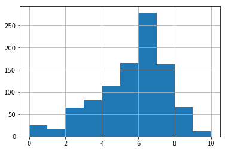

```python
df_20_08['greenhouse_gas_score'].hist()
```

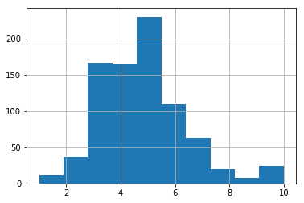

```python
df_20_18['greenhouse_gas_score'].hist()
```

A(1):-Distribution for 2008 is more skewed to the left.

q(2):-How has the distribution of combined mpg changed from 2008 to 2018?

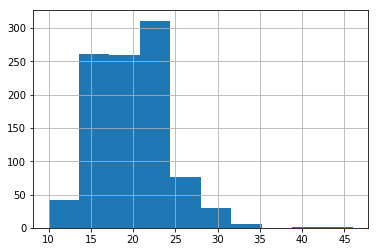

```python
df_20_08['cmb_mpg'].hist()
```

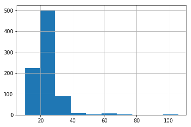

```python
df_20_18['cmb_mpg'].hist()
```

A(2):-Became much more skewed to the right

q(3):-Describe the correlation between displacement and combined mpg

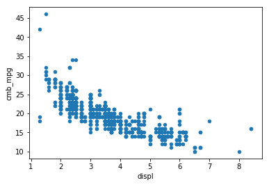

```python
df_20_08.plot(x='displ',y='cmb_mpg',kind='scatter')
```

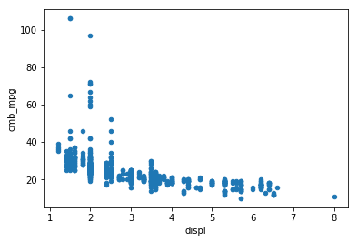

```python
df_20_18.plot(x='displ',y='cmb_mpg',kind='scatter')
```

A(3):-Negative correlation

q(4):-Describe the correlation between greenhouse gas score and combined mpg.

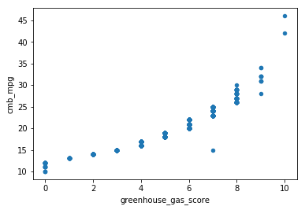

```python
df_20_08.plot(x='greenhouse_gas_score',y='cmb_mpg',kind='scatter')
```

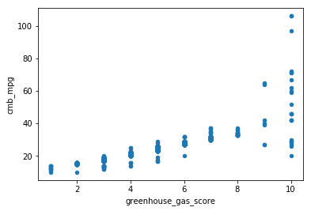

```python
df_20_18.plot(x='greenhouse_gas_score',y='cmb_mpg',kind='scatter')
```

A(4):-Positive correlation

# step(5):- Conclusions

# Q1: Are more unique models using alternative fuels in 2018 compared to 2008? By how much?

Let's first look at what the sources of fuel are and which ones are alternative sources

```python
df_20_08.fuel.value_counts()
```

```
Gasoline    984
CNG           1
ethanol       1
gas           1
Name: fuel, dtype: int64
```

```python
df_20_18.fuel.value_counts()
```

```
Gasoline       749
Ethanol         26
Gas             26
Diesel          19
Electricity     12
Name: fuel, dtype: int64
```

Looks like the alternative sources of fuel available in 2008 are CNG and ethanol, and those in 2018 ethanol and electricity. (You can use Google if you weren't sure which ones are alternative sources of fuel!)

```python
# how many unique models used alternative sources of fuel in 2008
alt_08 = df_20_08.query('fuel in ["CNG", "ethanol"]').model.nunique()
alt_08
```

```
2
```

```python
# how many unique models used alternative sources of fuel in 2018
alt_18 = df_20_18.query('fuel in ["Ethanol", "Electricity"]').model.nunique()
alt_18
```

```
26
```

Since 2008, the number of unique models using alternative sources of fuel increased by 24

```python
# total unique models each year
total_08 = df_20_08.model.nunique()
total_18 = df_20_18.model.nunique()
total_08, total_18
```

```
(377, 357)
```

```python
prop_08 = alt_08/total_08
prop_18 = alt_18/total_18
prop_08, prop_18
```

```
(0.005305039787798408, 0.07282913165266107)
```

# Q2: How much have vehicle classes improved in fuel economy?

Let's look at the average fuel economy for each vehicle class for both years

```python
veh_08 = df_20_08.groupby('veh_class').cmb_mpg.mean()
veh_08
```

```
veh_class
SUV              18.471429
large car        18.509091
midsize car      21.601449
minivan          19.117647
pickup           16.277108
small car        21.105105
station wagon    22.366667
van              14.952381
Name: cmb_mpg, dtype: float64
```

```python
veh_18 = df_20_18.groupby('veh_class').cmb_mpg.mean()
veh_18
```

```
veh_class
large car          23.409091
midsize car        27.884058
minivan            20.800000
pickup             18.589744
small SUV          24.074074
small car          25.421053
special purpose    18.500000
standard SUV       18.197674
station wagon      27.529412
Name: cmb_mpg, dtype: float64
```

```python
# how much they've increased by for each vehicle class
inc = veh_18 - veh_08
inc
```

```
veh_class
SUV                     NaN
large car          4.900000
midsize car        6.282609
minivan            1.682353
pickup             2.312635
small SUV               NaN
small car          4.315948
special purpose         NaN
standard SUV            NaN
station wagon      5.162745
van                     NaN
Name: cmb_mpg, dtype: float64
```

# Q3: What are the characteristics of SmartWay vehicles? Have they changed over time?

We can analyze this by filtering each dataframe by SmartWay classification and exploring these datasets

```python
# smartway labels for 2008
df_20_08.smartWay.unique()
```

```
array(['no', 'yes'], dtype=object)
```

```python
# get all smartway vehicles in 2008
smart_08 = df_20_08.query('smartWay == "yes"')
```

```python
# explore smartway vehicles in 2008
smart_08.describe()
```

|  | displ | cyl | air_pollution_score | city_mpg | hwy_mpg | cmb_mpg | greenhouse_gas_score |
| --- | --- | --- | --- | --- | --- | --- | --- |
| count | 380.000000 | 380.000000 | 380.000000 | 380.000000 | 380.000000 | 380.000000 | 380.000000 |
| mean | 2.602895 | 4.826316 | 7.365789 | 20.984211 | 28.413158 | 23.736842 | 6.868421 |
| std | 0.623436 | 1.002025 | 1.148195 | 3.442672 | 3.075194 | 3.060379 | 0.827338 |
| min | 1.300000 | 4.000000 | 6.000000 | 17.000000 | 22.000000 | 20.000000 | 6.000000 |
| 25% | 2.275000 | 4.000000 | 7.000000 | 19.000000 | 26.000000 | 22.000000 | 6.000000 |
| 50% | 2.400000 | 4.000000 | 7.000000 | 20.000000 | 28.000000 | 23.000000 | 7.000000 |
| 75% | 3.000000 | 6.000000 | 7.000000 | 22.000000 | 30.000000 | 25.000000 | 7.000000 |
| max | 5.000000 | 8.000000 | 9.500000 | 48.000000 | 45.000000 | 46.000000 | 10.000000 |

```python
# smartway labels for 2018
df_20_18.smartWay.unique()
```

```
array(['No', 'Yes', 'Elite'], dtype=object)
```

```python
# get all smartway vehicles in 2018
smart_18 = df_20_18.query('smartWay in ["Yes", "Elite"]')
```

```python
smart_18.describe()
```

|  | displ | cyl | air_pollution_score | city_mpg | hwy_mpg | cmb_mpg | greenhouse_gas_score |
| --- | --- | --- | --- | --- | --- | --- | --- |
| count | 108.000000 | 108.000000 | 108.000000 | 108.000000 | 108.000000 | 108.000000 | 108.000000 |
| mean | 1.787963 | 3.935185 | 5.212963 | 34.907407 | 41.472222 | 37.361111 | 7.925926 |
| std | 0.408031 | 0.416329 | 1.798498 | 16.431982 | 13.095236 | 14.848429 | 1.197378 |
| min | 1.200000 | 3.000000 | 3.000000 | 25.000000 | 27.000000 | 26.000000 | 7.000000 |
| 25% | 1.500000 | 4.000000 | 3.000000 | 28.000000 | 36.000000 | 31.000000 | 7.000000 |
| 50% | 1.700000 | 4.000000 | 5.500000 | 28.500000 | 37.000000 | 32.000000 | 7.000000 |
| 75% | 2.000000 | 4.000000 | 7.000000 | 31.250000 | 40.250000 | 35.000000 | 9.000000 |
| max | 3.500000 | 6.000000 | 7.000000 | 113.000000 | 99.000000 | 106.000000 | 10.000000 |